# Heyaojing Huang-Assignment4

Last modified time: October 16, 2021

## Bay area educational attainment by race

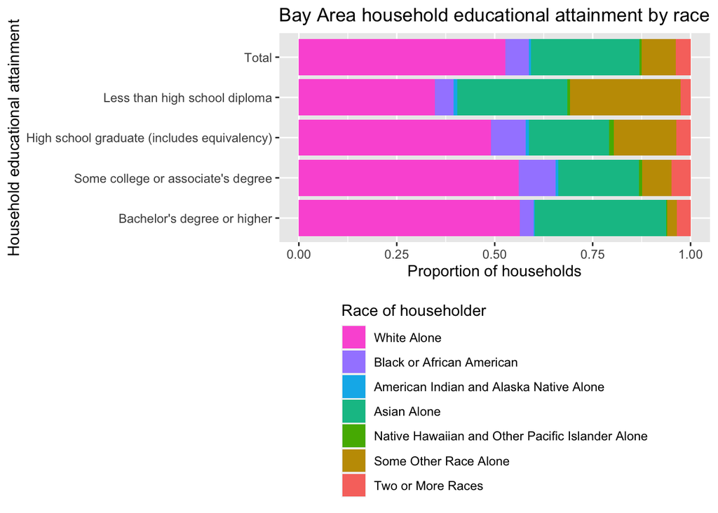

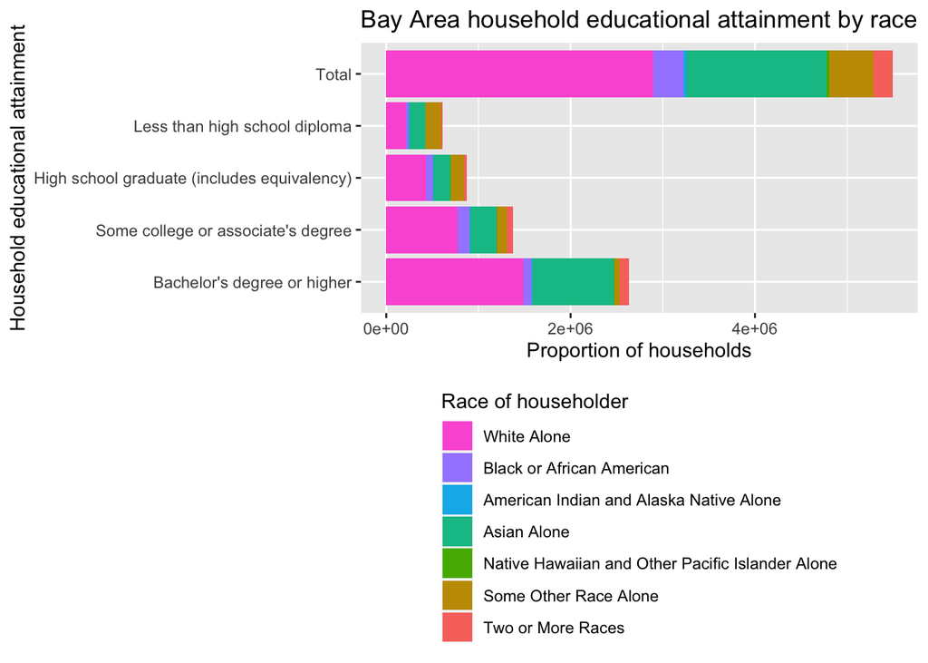

The above figures show that, among the population of 25+ years old in Bay Area, although White alone accounts for half of the population of the Bay Area, the proportion of this group who has obtained “less than high school diploma” is very low; the educational attainment of Asian alone is relatively balanced with its proportion of the total population. The educational attainment of some other races Alone groups is generally low, showing an inverted triangle pattern.

## Bay area educational attainment by ethnicity

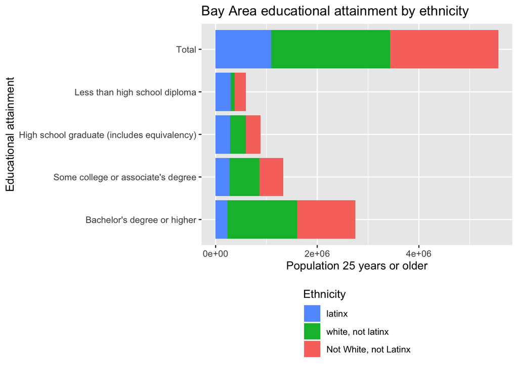

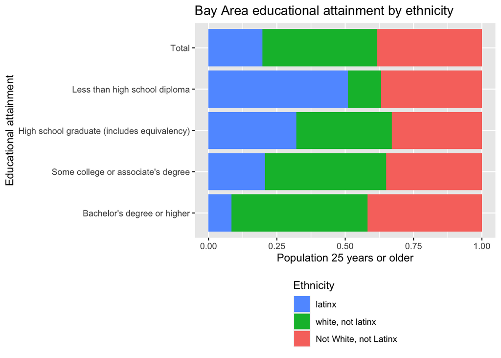

The above figures show that among the population of 25+ years old in Bay Area, the educational attainment of latinx is generally low, showing an inverted triangle distribution; the educational attainment of the white, not latinx group is mostly in bachelor’s degree or higher; the educational attainment of the not white, not latinx group is relatively balanced distribution.

## Latinx 25+ Population with no college degree

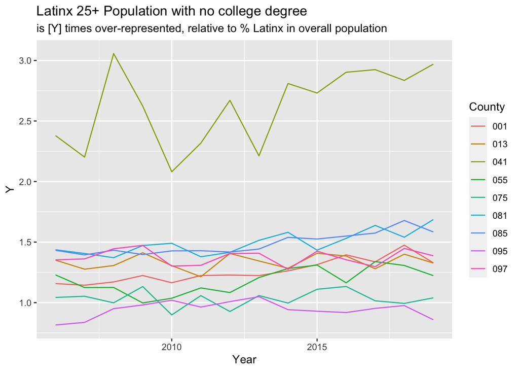

According to the chart “Latinx 25+ Population with no college degree”, among the population of 25+ years old in Bay Area, Marin County shows the biggest over-representation of the Latinx 25+ population who have no college degree. Also, from 2006-2019, educational attainment by ethnicity in Bay Area shows an upward trend, which means the Latinx 25+ population with no college degree are more over-representation over the years.